# capstone_data_vis

Daniel Cevallos

2023-07-14

### Data science Capstone project- Week 2 Assignment

The goal of this project is just to display that you’ve gotten used to working with the data and that you are on track to create your prediction algorithm. Please submit a report on R Pubs (http://rpubs.com/) that explains your exploratory analysis and your goals for the eventual app and algorithm. This document should be concise and explain only the major features of the data you have identified and briefly summarize your plans for creating the prediction algorithm and Shiny app in a way that would be understandable to a non-data scientist manager. You should make use of tables and plots to illustrate important summaries of the data set. The motivation for this project is to: 1. Demonstrate that you’ve downloaded the data and have successfully loaded it in.2. Create a basic report of summary statistics about the data sets.3. Report any interesting findings that you amassed so far.4. Get feedback on your plans for creating a prediction algorithm and Shiny app. ** REVIEW CRITERIA:** 1. Does the link lead to an HTML page describing the exploratory analysis of the training data set? 2. Has the data scientist done basic summaries of the three files? Word counts, line counts and basic data tables? 3. Has the data scientist made basic plots, such as histograms to illustrate features of the data? 4. Was the report written in a brief, concise style, in a way that a non-data scientist manager could appreciate?

### LOADING THE DATA AND LIBRARIES IN R

```r
library("ggplot2")
library("tm")
library("wordcloud")
library("quanteda")
library("tufte")
```

The dataset is downloadable in zipped file via [here](https://d396qusza40orc.cloudfront.net/dsscapstone/dataset/Coursera-SwiftKey.zip).

```r
if(!file.exists('data/')) dir.create('data/')

lnk <- 'https://d396qusza40orc.cloudfront.net/dsscapstone/dataset/Coursera-SwiftKey.zip'
destfile <- 'Coursera-SwiftKey.zip'

if(!file.exists(paste0('data/', destfile))) {
  download.file(lnk, destfile = paste0('data/', destfile))
}

if(!file.exists(paste0('data/final'))) {
  ## Unzip the dataset
  #'@ unzip(paste0('data/', destfile), exdir = 'data/final/de_DE', list = TRUE)
  # Error in unzip(paste0("data/", destfile), exdir = "data/final/de_DE",  :
  #   'exdir' does not exist
  unzip(paste0('data/', destfile), exdir = 'data/')
}

## list down the details of the zipped file
unzip(paste0('data/', destfile), list = TRUE)
```

```
                            Name    Length                Date
1                         final/         0 2014-07-22 10:10:00
2                   final/de_DE/         0 2014-07-22 10:10:00
3  final/de_DE/de_DE.twitter.txt  75578341 2014-07-22 10:11:00
4    final/de_DE/de_DE.blogs.txt  85459666 2014-07-22 10:11:00
5     final/de_DE/de_DE.news.txt  95591959 2014-07-22 10:11:00
6                   final/ru_RU/         0 2014-07-22 10:10:00
7    final/ru_RU/ru_RU.blogs.txt 116855835 2014-07-22 10:12:00
8     final/ru_RU/ru_RU.news.txt 118996424 2014-07-22 10:12:00
9  final/ru_RU/ru_RU.twitter.txt 105182346 2014-07-22 10:12:00
10                  final/en_US/         0 2014-07-22 10:10:00
11 final/en_US/en_US.twitter.txt 167105338 2014-07-22 10:12:00
12    final/en_US/en_US.news.txt 205811889 2014-07-22 10:13:00
13   final/en_US/en_US.blogs.txt 210160014 2014-07-22 10:13:00
14                  final/fi_FI/         0 2014-07-22 10:10:00
15    final/fi_FI/fi_FI.news.txt  94234350 2014-07-22 10:11:00
16   final/fi_FI/fi_FI.blogs.txt 108503595 2014-07-22 10:12:00
17 final/fi_FI/fi_FI.twitter.txt  25331142 2014-07-22 10:10:00
```

### Dataset summaries

```r
size_blogs<-file.size(path="data/final/en_US/en_US.blogs.txt")/2^20
size_news<-file.size(path="data/final/en_US/en_US.news.txt")/2^20
size_twitter<-file.size(path="data/final/en_US/en_US.twitter.txt")/2^20

len_blogs<-length(blogs)
len_news<-length(news)
len_twitter<-length(twitter)

nchar_blogs<-sum(nchar(blogs))
nchar_news<-sum(nchar(news))
nchar_twitter<-sum(nchar(twitter))

library(stringi)
nword_blogs<-stri_stats_latex(blogs)[4]
nword_news<-stri_stats_latex(news)[4]
nword_twitter<-stri_stats_latex(twitter)[4]

table<-data.frame("File Name"=c("Blogs","News","Twitter"),
                  "File Size(MB)"=c(size_blogs,size_news,size_twitter),
                  "Num of rows"=c(len_blogs,len_news,len_twitter),
                  "Num of character"=c(nchar_blogs,nchar_news,nchar_twitter),
                  "Num of words"=c(nword_blogs,nword_news,nword_twitter))

table
```

```
  File.Name File.Size.MB. Num.of.rows Num.of.character Num.of.words
1     Blogs      200.4242      899288        206824509     37570839
2      News      196.2775       77259         15639408      2651432
3   Twitter      159.3641     2360148        162122651     30451128
```

### Cleaning the data

Here we will make the test data of the given corpus which will require cleaning of the given corpus data… hence first we’ll clean the given data nd the then take out a sample from and that will be our test data and then we’ll see which words has the highest frequency..

```r
set.seed(12345)

blogs1<-iconv(blogs,"latin1","ASCII",sub="")
news1<-iconv(news,"latin1","ASCII",sub="")
twitter1<-iconv(twitter,"latin1","ASCII",sub="")

rm(blogs)
rm(news)
rm(twitter)

# sample data set only 1% of each file
sample_data<-c(sample(blogs1,length(blogs1)*0.01),
               sample(news1,length(news1)*0.01),
               sample(twitter1,length(twitter1)*0.01))

rm(blogs1)
rm(news1)
rm(twitter1)

make_corpus <- function(test_file){
  gen_corp <- paste(test_file, collapse = " ")
  gen_corp<- VectorSource(gen_corp)
  gen_corp <- Corpus(gen_corp)
}

clean_corp <- function(corp_data){
  corp_data <- tm_map(corp_data, removeNumbers)
  corp_data <- tm_map(corp_data, content_transformer(tolower))
  corp_data<- tm_map(corp_data, removeWords, stopwords("english"))
  corp_data<- tm_map(corp_data, removePunctuation)
  corp_data<- tm_map(corp_data, stripWhitespace)
  return (corp_data)
}
high_freq_words <-  function(corp_data){
  term_sparse <- DocumentTermMatrix(corp_data)
  #convert our term-document-matrix into normal matrix
  term_matrix <- as.matrix(term_sparse)
  freq_words <- colSums(term_matrix)
  freq_words <- as.data.frame(sort(freq_words, decreasing = TRUE))
  freq_words$words <- rownames(freq_words)
  colnames(freq_words) <- c("frequency", "word")
  return(freq_words)
}
```

### Build N-gram

```r
library(RWeka)

one<-function(x) NGramTokenizer(x,Weka_control(min=1,max=1))
two<-function(x) NGramTokenizer(x,Weka_control(min=2,max=2))
thr<-function(x) NGramTokenizer(x,Weka_control(min=3,max=3))

one_table<-TermDocumentMatrix(corpus6,control=list(tokenize=one))
two_table<-TermDocumentMatrix(corpus6,control=list(tokenize=two))
thr_table<-TermDocumentMatrix(corpus6,control=list(tokenize=thr))

one_corpus<-findFreqTerms(one_table,lowfreq=1000)
two_corpus<-findFreqTerms(two_table,lowfreq=80)
thr_corpus<-findFreqTerms(thr_table,lowfreq=10)

one_corpus_num<-rowSums(as.matrix(one_table[one_corpus,]))
one_corpus_table<-data.frame(Word=names(one_corpus_num),frequency=one_corpus_num)
one_corpus_sort<-one_corpus_table[order(-one_corpus_table$frequency),]
head(one_corpus_sort)
```

```
     Word frequency
just just      2576
like like      2218
one   one      2049
get   get      1869
can   can      1866
time time      1639
```

```r
two_corpus_num<-rowSums(as.matrix(two_table[two_corpus,]))
two_corpus_table<-data.frame(Word=names(two_corpus_num),frequency=two_corpus_num)
two_corpus_sort<-two_corpus_table[order(-two_corpus_table$frequency),]
head(two_corpus_sort)
```

```
                 Word frequency
cant wait   cant wait       208
right now   right now       206
dont know   dont know       164
last night last night       148
im going     im going       130
feel like   feel like       125
```

```r
thr_corpus_num<-rowSums(as.matrix(thr_table[thr_corpus,]))
thr_corpus_table<-data.frame(Word=names(thr_corpus_num),frequency=thr_corpus_num)
thr_corpus_sort<-thr_corpus_table[order(-thr_corpus_table$frequency),]
head(thr_corpus_sort)
```

```
                                     Word frequency
cant wait see               cant wait see        45
happy mothers day       happy mothers day        36
happy new year             happy new year        24
im pretty sure             im pretty sure        18
italy lakes holidays italy lakes holidays        18
little italy boston   little italy boston        17
```

### Bar Chart of Frequency words

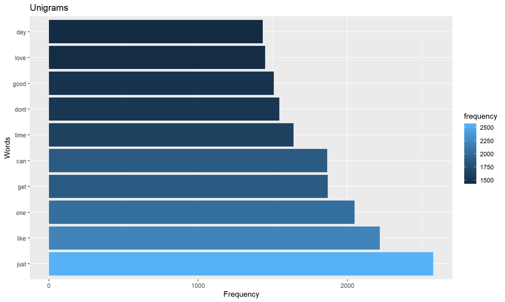

```r
library(ggplot2)

one_g<-ggplot(one_corpus_sort[1:10,],aes(x=reorder(Word,-frequency),y=frequency,fill=frequency))
one_g<-one_g+geom_bar(stat="identity")
one_g<-one_g+labs(title="Unigrams",x="Words",y="Frequency")
one_g<-one_g+coord_flip()
one_g
```

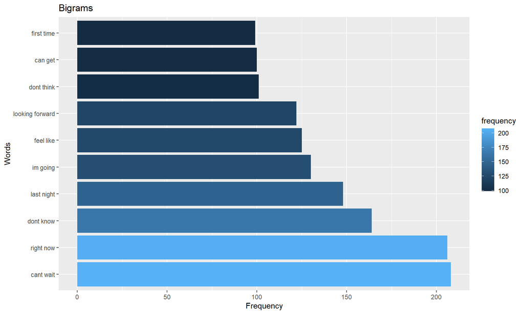

```r
two_g<-ggplot(two_corpus_sort[1:10,],aes(x=reorder(Word,-frequency),y=frequency,fill=frequency))
two_g<-two_g+geom_bar(stat="identity")
two_g<-two_g+labs(title="Bigrams",x="Words",y="Frequency")
two_g<-two_g+coord_flip()
two_g
```

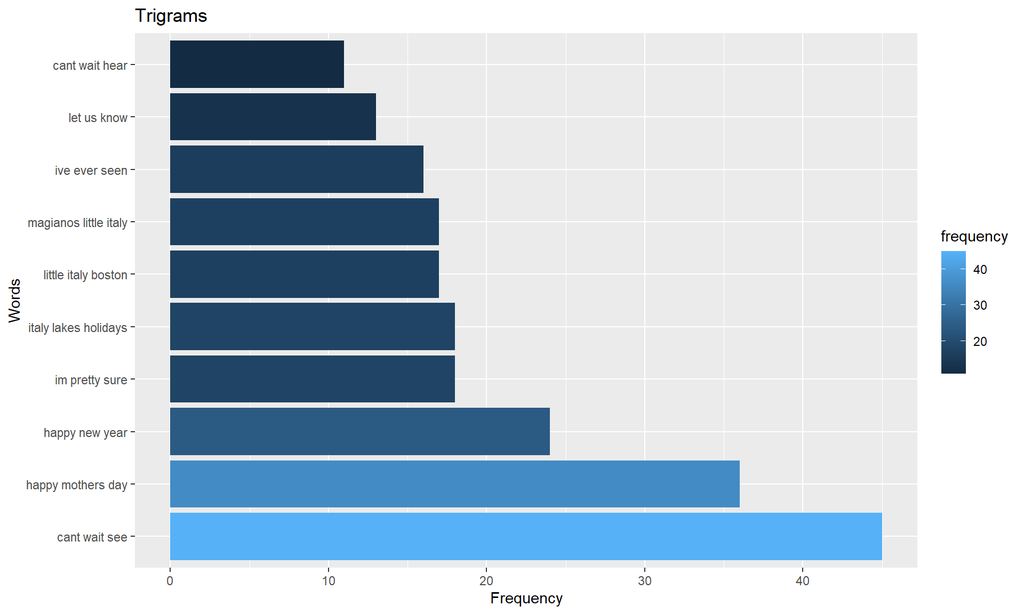

```r
# High frequency words in twitter
thr_g<-ggplot(thr_corpus_sort[1:10,],aes(x=reorder(Word,-frequency),y=frequency,fill=frequency))
thr_g<-thr_g+geom_bar(stat="identity")
thr_g<-thr_g+labs(title="Trigrams",x="Words",y="Frequency")
thr_g<-thr_g+coord_flip()
thr_g
```

### Next plans

Must be make a predictive algorithm, using shiny(), I will check the result which input is coming.